# ch-9-additional-linear-modeling-topics

Sonya Hua

September 16, 2017

4 additional topics on linear model is discussed here:

- **Handling highly correlated observations or collinearity** Ways to detect and remediate collinearity in a data set
- **Fidding models with binary outcomes or logistic regression** Such as whether a customer will purchase ap roduct or not
- **Modeling individual preferences and responses as well as group-level effects using Hierarchical linear models (HLM)** for consumer preference in ratings-based conjoint analysis
- **Using Bayesian methods for hierarchical models of individual preference** whereby we apply hierarchical bayesian (HB) for artings-based conjoint analysi

Each topic is a foundational part of a complete toolbox for marketing analysis

### 9.1. Handling HIghtly Correlated Variables

##### Which variables are most predictive of online spending?

```r
cust.df <- read.csv("http://goo.gl/PmPkaG")
summary(cust.df)
```

```
##     cust.id            age         credit.score   email
##  Min.   :   1.0   Min.   :19.34   Min.   :543.0   no :186
##  1st Qu.: 250.8   1st Qu.:31.43   1st Qu.:691.7   yes:814
##  Median : 500.5   Median :35.10   Median :725.5
##  Mean   : 500.5   Mean   :34.92   Mean   :725.5
##  3rd Qu.: 750.2   3rd Qu.:38.20   3rd Qu.:757.2
##  Max.   :1000.0   Max.   :51.86   Max.   :880.8
##
##  distance.to.store  online.visits     online.trans      online.spend
##  Min.   :  0.2136   Min.   :  0.00   Min.   :  0.000   Min.   :   0.00
##  1st Qu.:  3.3383   1st Qu.:  0.00   1st Qu.:  0.000   1st Qu.:   0.00
##  Median :  7.1317   Median :  6.00   Median :  2.000   Median :  37.03
##  Mean   : 14.6553   Mean   : 28.29   Mean   :  8.385   Mean   : 170.32
##  3rd Qu.: 16.6589   3rd Qu.: 31.00   3rd Qu.:  9.000   3rd Qu.: 177.89
##  Max.   :267.0864   Max.   :606.00   Max.   :169.000   Max.   :3593.03
##
##   store.trans      store.spend      sat.service   sat.selection
##  Min.   : 0.000   Min.   :  0.00   Min.   :1.00   Min.   :1.000
##  1st Qu.: 0.000   1st Qu.:  0.00   1st Qu.:3.00   1st Qu.:2.000
##  Median : 1.000   Median : 30.05   Median :3.00   Median :2.000
##  Mean   : 1.323   Mean   : 47.58   Mean   :3.07   Mean   :2.401
##  3rd Qu.: 2.000   3rd Qu.: 66.49   3rd Qu.:4.00   3rd Qu.:3.000
##  Max.   :12.000   Max.   :705.66   Max.   :5.00   Max.   :5.000
##                                    NA's   :341    NA's   :341
```

```r
spend.m1 <-lm(online.spend ~.,
              data=subset(cust.df[,-1], online.spend >0)) # Subset data where online spend is > 0 and omit cust ID column

summary(spend.m1)
```

```
##
## Call:
## lm(formula = online.spend ~ ., data = subset(cust.df[, -1], online.spend >
##     0))
##
## Residuals:
##      Min       1Q   Median       3Q      Max
## -234.097   -8.828    0.519    9.956  227.238
##
## Coefficients:
##                    Estimate Std. Error t value Pr(>|t|)
## (Intercept)        6.718948  33.537665   0.200   0.8413
## age                0.422773   0.450825   0.938   0.3489
## credit.score      -0.033698   0.043977  -0.766   0.4440
## emailyes          -5.689283   5.806621  -0.980   0.3278
## distance.to.store -0.043548   0.100539  -0.433   0.6651
## online.visits     -0.072269   0.204061  -0.354   0.7234
## online.trans      20.610744   0.667450  30.880   <2e-16 ***
## store.trans        0.135018   3.211943   0.042   0.9665
## store.spend        0.001796   0.078732   0.023   0.9818
## sat.service        5.638769   3.016181   1.870   0.0623 .
## sat.selection     -4.370606   2.909073  -1.502   0.1338
## ---
## Signif. codes:  0 '***' 0.001 '**' 0.01 '*' 0.05 '.' 0.1 ' ' 1
##
## Residual standard error: 42.77 on 407 degrees of freedom
##   (214 observations deleted due to missingness)
## Multiple R-squared:  0.9831, Adjusted R-squared:  0.9827
## F-statistic:  2363 on 10 and 407 DF,  p-value: < 2.2e-16
```

*Obs*:

- Online spend is closely related to the # of online transactions but not to the number of online visits, which is confusing
- The model accounts for almost all theavailable variance (R^2 = .98). This should raise red flag. Shoulded results for online visits be signficant as well since ionline trans dpends on online visits?
- The standard error on store transactions is large (3.21 SE, coeff=0.135), showing that its estimate is unstable

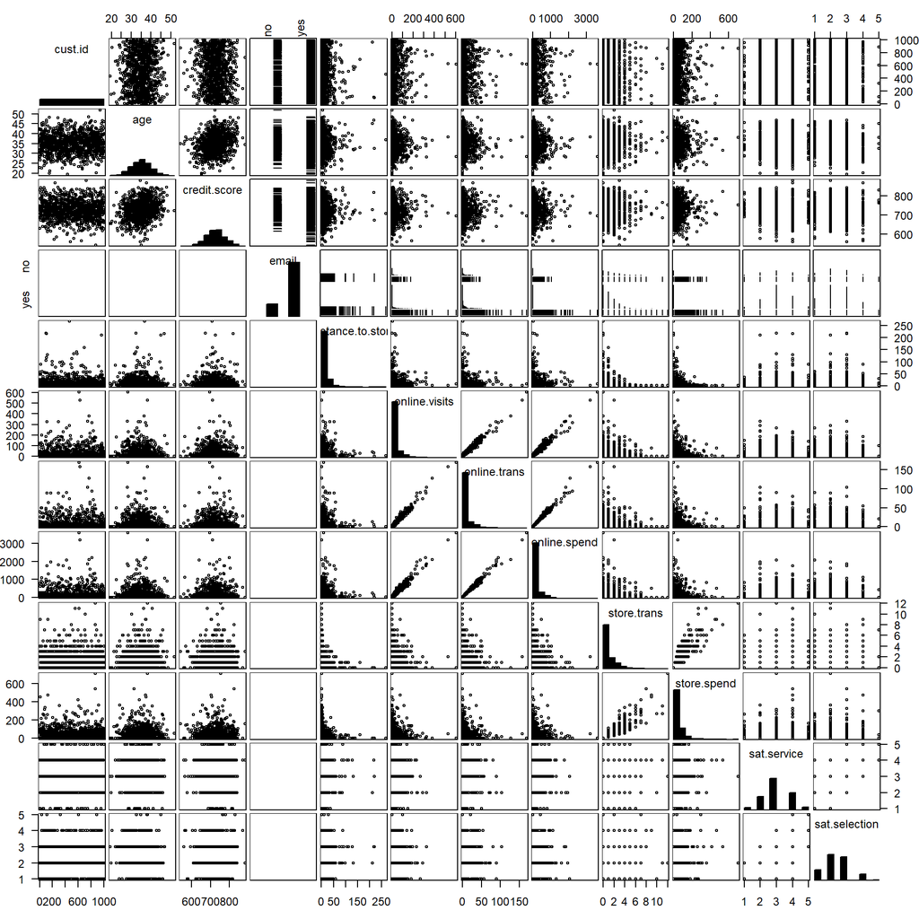

```r
library(gpairs)
gpairs(cust.df)
```

*Obs*:

- There are some variables with extreme skew
- Ther eare pairwase variables that are nearly correlated such as online visits and online trans, store trans and store spend

Both situations pose problems for linear regression:

1. Our first step is to remediate the situation by **transforming** the data using Box-Cox trasnformation from `forecast` package to select the transformation lambda automatically. We’ll create a function.`BoxCox(object)`: Computes and optionally plots profile log-likelihoods for the parameter of the Box-Cox power transformation.
2. At the same time, we can **standardize** the data with `scale()`. See Sec 4.5.5 on BoxCox
3. We select the complete cases from our data frame, dropping the customer ID column since it’s not a predictor. `complete.cases()` return a logical vector indicating which cases are complete, i.e., have no missing values.
4. Then we only take rows with positive online spend ( > 0) using `subset()`
5. Create a vector to index all columns except `email` which isn’t numeric using `which()` : Gives the TRUE indices of a logical object, allowing for array indices.
6. lapply() the `autoTransform()` function we just created to each numeric column

```r
# Step 1 and 2
#install.packages("forecast")
autoTransform <- function(x) {
  library(forecast)
  return(scale(BoxCox(x, BoxCox.lambda(x))))
}

# Step 3 Select rows with complete cases
cust.df.bc <- cust.df[complete.cases(cust.df), -1]

# Step 4
cust.df.bc <- subset(cust.df.bc, online.spend > 0)

# Step 5 - Create a vector of column names
numcols<- which(colnames(cust.df.bc) !="email")

#Step 6 - lapply the autotransform to each numeric column
cust.df.bc[,numcols] <- lapply(cust.df.bc[,numcols], autoTransform)

# Check work
summary(cust.df.bc)
```

```
##         age.V1          credit.score.V1   email     distance.to.store.V1
##  Min.   :-2.6028151   Min.   :-3.549645   no : 67   Min.   :-4.151249
##  1st Qu.:-0.6102340   1st Qu.:-0.664190   yes:351   1st Qu.:-0.642231
##  Median : 0.0319899   Median : 0.024254             Median : 0.110540
##  Mean   : 0.0000000   Mean   : 0.000000             Mean   : 0.000000
##  3rd Qu.: 0.6444580   3rd Qu.: 0.687857             3rd Qu.: 0.723209
##  Max.   : 2.4751221   Max.   : 2.691592             Max.   : 2.235170
##    online.visits.V1     online.trans.V1      online.spend.V1
##  Min.   :-2.5478012   Min.   :-1.6105773   Min.   :-1.9847582
##  1st Qu.:-0.6422584   1st Qu.:-0.9065743   1st Qu.:-0.7686352
##  Median : 0.1265838   Median : 0.1092692   Median : 0.1358798
##  Mean   : 0.0000000   Mean   : 0.0000000   Mean   : 0.0000000
##  3rd Qu.: 0.8231873   3rd Qu.: 0.8739755   3rd Qu.: 0.8897866
##  Max.   : 1.7768679   Max.   : 1.8204545   Max.   : 1.7784232
##     store.trans.V1       store.spend.V1       sat.service.V1
##  Min.   :-1.3303670   Min.   :-1.3373428   Min.   :-2.2411659
##  1st Qu.:-1.3303670   1st Qu.:-1.3373428   1st Qu.:-0.0917797
##  Median : 0.5382470   Median : 0.5997467   Median :-0.0917797
##  Mean   : 0.0000000   Mean   : 0.0000000   Mean   : 0.0000000
##  3rd Qu.: 0.7660742   3rd Qu.: 0.7674898   3rd Qu.: 1.1080508
##  Max.   : 1.3605408   Max.   : 1.2717696   Max.   : 2.3654420
##    sat.selection.V1
##  Min.   :-1.6476883
##  1st Qu.:-0.3270153
##  Median :-0.3270153
##  Mean   : 0.0000000
##  3rd Qu.: 0.7455990
##  Max.   : 2.5321752
```

```r
head(cust.df.bc)
```

```
##           age credit.score email distance.to.store online.visits
## 1  -2.4289529  -1.93385008   yes       -0.94785696    0.05805482
## 2  -1.2872365   0.49555915   yes        1.41401190    1.22896924
## 5   0.9128149   0.20798989    no        0.98442207    0.44946213
## 7  -1.2346944   0.02572405   yes        0.23794532   -2.54780116
## 8   0.4659793   0.49558759   yes       -0.01619594    0.65906657
## 10 -1.6042591   1.21453269    no       -0.05469028   -0.20545270
##    online.trans online.spend store.trans store.spend sat.service
## 1   -0.53240767  -0.55554635   1.0216787   0.9457336 -0.09177965
## 2    1.31082233   1.27381034  -1.3303670  -1.3373428 -0.09177965
## 5    0.50346426   0.45244103  -1.3303670  -1.3373428 -2.24116588
## 7   -1.61057727  -1.70800915   0.7660742   0.7551173 -0.09177965
## 8    0.62047038   0.60753351   1.0216787   0.7936471 -1.21839266
## 10   0.04922013   0.07635248   0.9120130   0.8703658 -0.09177965
##    sat.selection
## 1      0.7455990
## 2      0.7455990
## 5     -1.6476883
## 7      0.7455990
## 8      0.7455990
## 10    -0.3270153
```

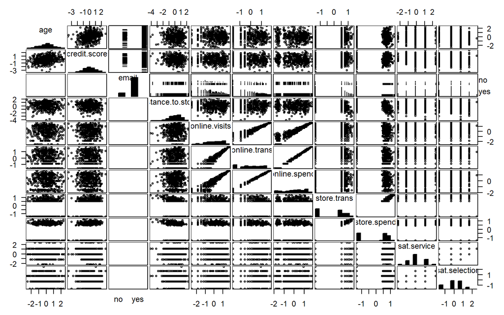

```r
gpairs(cust.df.bc)
```

*Obs*: We now have a df with standardized, more normally distributed values

```r
# refine the model using transformed df

spend.m2<-lm(online.spend ~ ., data=cust.df.bc)
summary(spend.m2)
```

```
##
## Call:
## lm(formula = online.spend ~ ., data = cust.df.bc)
##
## Residuals:
##      Min       1Q   Median       3Q      Max
## -0.38976 -0.05409  0.00027  0.05591  0.26628
##
## Coefficients:
##                     Estimate Std. Error t value Pr(>|t|)
## (Intercept)       -0.0059639  0.0108943  -0.547    0.584
## age                0.0001875  0.0044821   0.042    0.967
## credit.score      -0.0026632  0.0045185  -0.589    0.556
## emailyes           0.0071023  0.0119316   0.595    0.552
## distance.to.store -0.0020362  0.0048800  -0.417    0.677
## online.visits     -0.0003913  0.0126165  -0.031    0.975
## online.trans       0.9960378  0.0126687  78.622   <2e-16 ***
## store.trans       -0.0266674  0.0480675  -0.555    0.579
## store.spend        0.0274099  0.0475888   0.576    0.565
## sat.service        0.0059429  0.0052732   1.127    0.260
## sat.selection      0.0030628  0.0052624   0.582    0.561
## ---
## Signif. codes:  0 '***' 0.001 '**' 0.01 '*' 0.05 '.' 0.1 ' ' 1
##
## Residual standard error: 0.08747 on 407 degrees of freedom
## Multiple R-squared:  0.9925, Adjusted R-squared:  0.9923
## F-statistic:  5410 on 10 and 407 DF,  p-value: < 2.2e-16
```

*Obs*:

- coefficients are smaller now since the data has been standardized.
- Transforming and standardiing the data, has not corrected there unrealistic estimate that onlien spend is highly related to ransfasctions yet unrelated to visits. We can confirm this using ANOVA:

```r
spend.m3 <-lm(online.spend ~ online.trans, data=cust.df.bc)

# compare full model vs. model with spend ~ online. trans only
anova(spend.m2, spend.m3)
```

```
## Analysis of Variance Table
##
## Model 1: online.spend ~ age + credit.score + email + distance.to.store +
##     online.visits + online.trans + store.trans + store.spend +
##     sat.service + sat.selection
## Model 2: online.spend ~ online.trans
##   Res.Df    RSS Df Sum of Sq      F Pr(>F)
## 1    407 3.1139
## 2    416 3.1539 -9 -0.040001 0.5809 0.8129
```

*Obs*:

- Full model is noo better than the one that simply predicts spending from online trans online. Thus, the null hypothesis of no difference between models can’t be rejected.

The main problem here is *collinearity*: because visits and transactions are so highly related, and also linear regresssion assuems that effects are additive, an effected attributed to one var (.e. trans) is not available in the model to be attributed jointly to another thawt’s hghly correlated. This will cause the standard errors to increase, which means that the coefficient estimates will be hgihly unstaable.

#### 9.1.2 Remediating Collinearity

*Variance inflation factor (VIF)* is the degree of collinearity in data and measures the variance (standard error) of a coefficient in a linear regression that’s increased due to shared variance with other variables vs. if variables were uncorrelated. We use `vif()` from car package

*VIF > 5 = the need to mitigate collinearity

```r
library(car)
print(vif(spend.m2))
```

```
##               age      credit.score             email distance.to.store
##          1.094949          1.112784          1.046874          1.297978
##     online.visits      online.trans       store.trans       store.spend
##          8.675817          8.747756        125.931383        123.435407
##       sat.service     sat.selection
##          1.515576          1.509377
```

*Obs* VIF suggests that we need to rematdiate collinearity for online.visits, online.trans, store.trans,store.spend

#### There’s 4 ways to mitigate collinearity:

1. Remove vars athat are highly correlated
2. Extract principal components or factors for sets of highly correlated predictors
3. Use a stat. method that’s robust to collinearity such as a random forest which only uses a subset of vars at a time
4. Construct a new var that combines the collinear variables (suc has spend per transaction)..

#### Case 1. Remove highly correlated variables (online trans, store trans)

Using “-” in the formula

```r
spend.m4 <- lm(online.spend ~.-online.trans -store.trans, data=cust.df.bc)

# Check variance inflation factor of vars
library(car)
vif(spend.m4)
```

```
##               age      credit.score             email distance.to.store
##          1.081411          1.103586          1.033945          1.211607
##     online.visits       store.spend       sat.service     sat.selection
##          1.026148          1.215208          1.507866          1.509001
```